# Sexism Revisited Or Why Our Kids Should Listen To Jazz

Parenting in the twenty-first century is not an easy endeavor. Yet, the values we teach our children are core to a sustainable and just future. Today, the idea of gender equality is heavily fostered by parents around the globe. Some parents seem more successful in doings so than others. It seems that our everyday environment has a big effect.

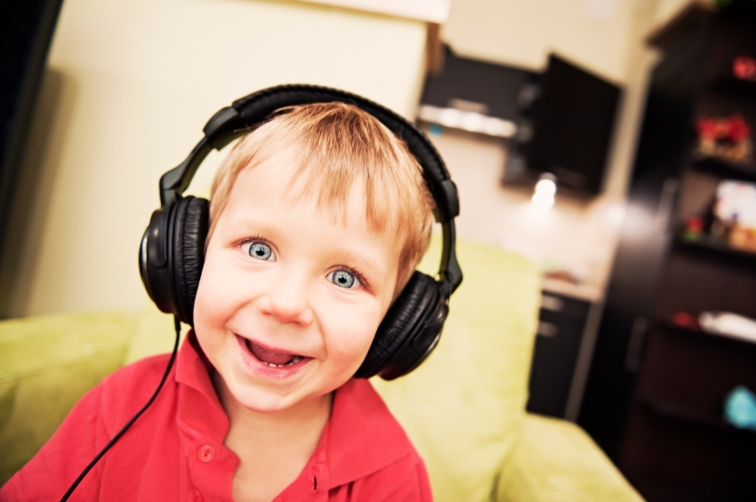

Many of us take very good care with whom our children play or what movies they watch. When it comes to music, however, one of the few paradigms seems to be that Hip-Hop music is detrimental to our kids’ growing value sets. We often connect Hip-Hop with explicit sexism. And this might be justified. But what about other genres: How are women portrayed in Jazz, Pop, or Metal? And in which genre are songs about women most positive?

This data story is a journey through the traces of implicit sexism in our everyday (music) life. You will learn which genre might be best for your kids and whether the music you are listening to while driving your kids to school is as progressive as it sounds.

### Are songs from certain genres talking more negative about women than others?

Let’s give it a start. In the following bar plot we see that there certainly is a big difference in songs about women between various genres:

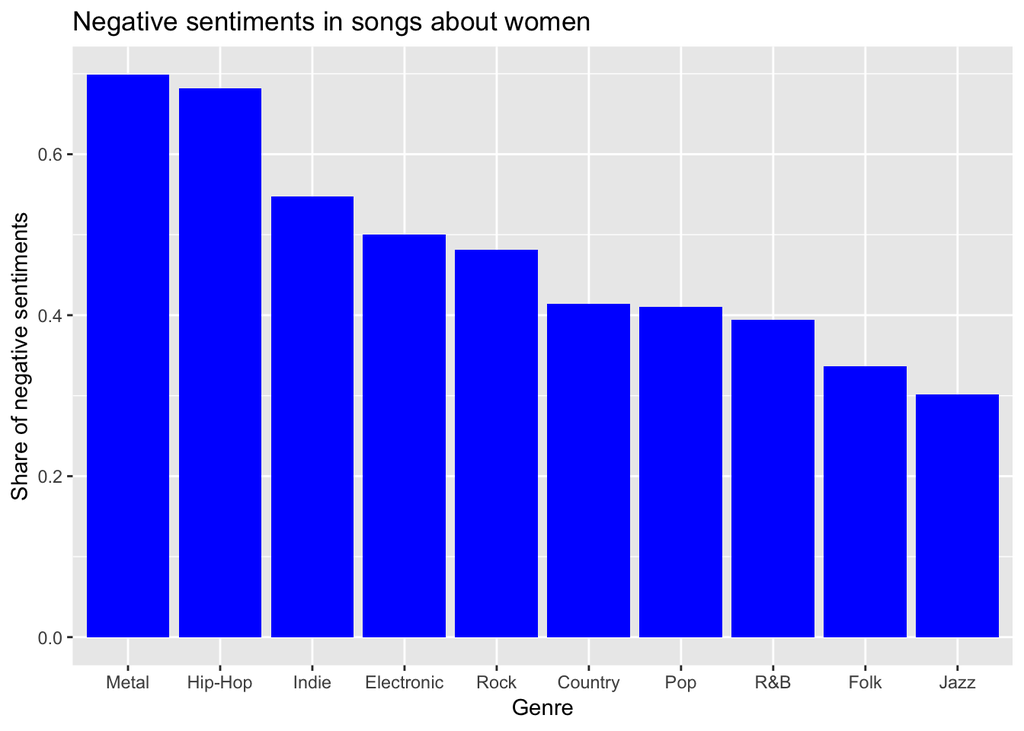

To Metal fans, the results might be breathtaking. The plot clearly shows that Metal as well as Hip-Hop songs about women are by far the songs with the highest shares of negative sentiments. Jazz and Folk songs, however, seem to talk the most positive about women.

### A positive note: What makes Jazz songs about women so nice?

The word cloud with dominant terms in Jazz songs about women is full of “love”. Probably, this does not come surprisingly to you since many songs we know are about love.

However, some of you might argue that certain dominant terms here could even be perceived as sexist. It should be noted though that this word cloud gives an overall positive impression.

[interactive chart not shown]

### And what makes makes Metal songs about women so negative?

Despite the fact that also “love” seems to be a dominant element in Metal songs, we can find much darker words such as “black”, “blood”, or “burn”. And death itself seems to be a very prominent pattern…

[interactive chart not shown]

### Let’s take a look at Hip-Hop: What are the relevant topics there?

Well, it’s commonly known that Hip-Hop portrays women in a negative way. The graph below gives us insights into potential topics of songs about women. We clearly see that the topics of Hip-Hop songs about women are interestingly about love to women, about money and showing-off, as well as about a very negative view on women.

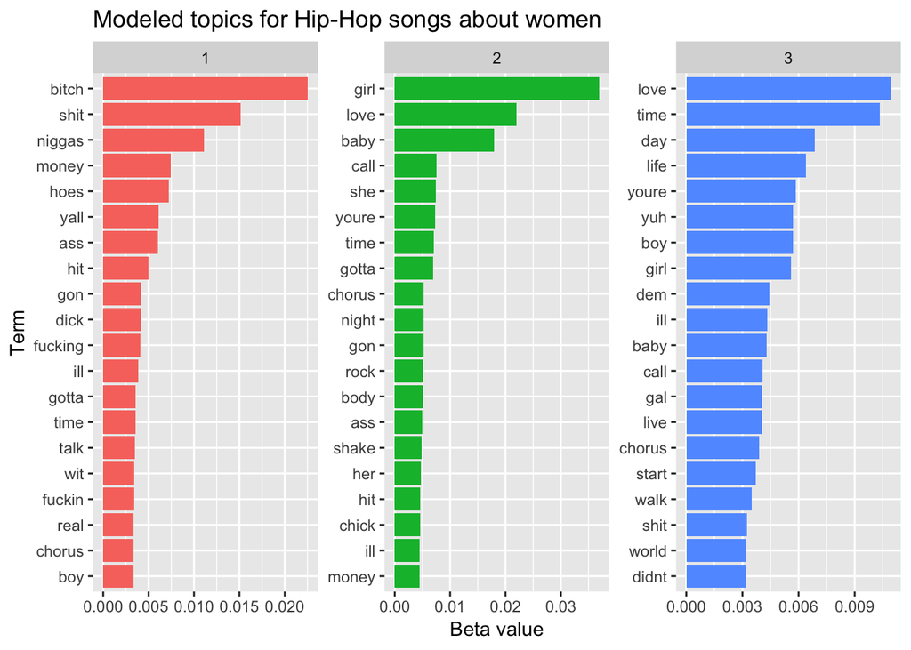

### Finally: Where are we heading?

So far, we have looked at quite some genres and their characters. You might wonder: Is there a special development over time? Did - as awareness about sexism increased - songs become less negative when talking about women? Here is the result for Hip-Hop, Jazz, and Metal for the development over the last ten years that data was available:

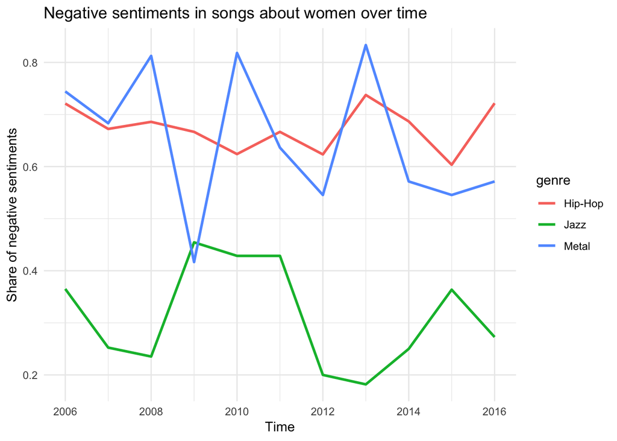

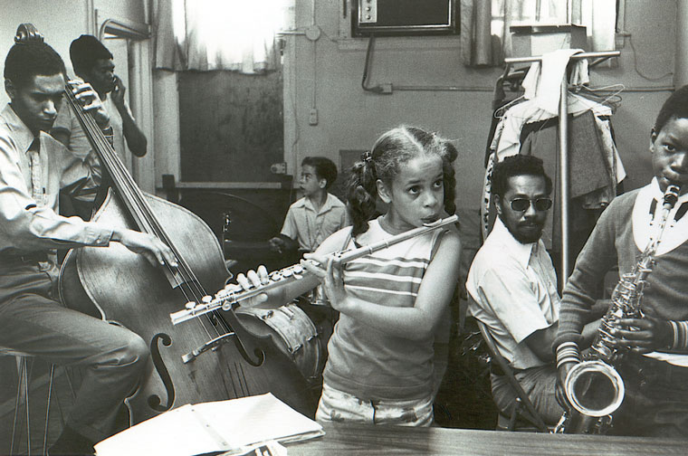